# index

Exploring Bike Rental Trends

*A Python Analysis Project*

Anna Carolina Corrêa

Prof. Chase Kusterer  
Hult International Business School - San Francisco  
Introduction to Python

･*:.｡. .｡.:*･゜ﾟ･*☆･*:.｡. .｡.:*･゜ﾟ･*☆･*:.｡. .｡.:*･゜ﾟ･*☆･*:.｡. .｡.:*･゜ﾟ･*☆･*:.｡. .｡.:*･゜ﾟ･*☆･*:.｡. .｡.:*･゜ﾟ･*☆･*:.｡. .｡.:*･゜ﾟ･*☆･*:.｡. .｡.:*･゜ﾟ･*☆･*:.｡. .｡.:*･゜ﾟ･*☆･*:.｡. .｡.:*･゜ﾟ･*☆･*:.｡. .｡.:*･゜ﾟ･*☆･*:

# Introduction

In this project, we will analyze bicycle's rental demand to uncover which factors impact the customers' preference for using our service. We will compare temporal features, weather conditions, holidays indicators, and other relevant variables using diversified data visualizations and descriptive analytics. By employing boxplots, scatter plots, and heatmaps weaim to reveal key relationships and impact of those factors. These insights will lead us through the development of actionable recommendations to optimize operations and maximize rental results. When these key patterns are identified, it is possible to translate the extensive, complex figures into data-driven strategies that will enhance customer satisfaction.

# Key Insights

These findings can be confirmed by prior studies that support the facts that:

- Bicycle users are sensitive to weather, and temperature is the strongest driver;
- Bikes are commonly used during peak hours, especially to go to work, which is the second most frequent trip purpose after going back home.

## References:

Dill, J., & Gliebe, J. (2008). Understanding and measuring bicycling behavior: A focus on travel time and route choice (Final Report No. OTREC-RR-08-03). Oregon Transportation Research and Education Consortium. https://nacto.org/wp-content/uploads/Dill-and-Gliebe-2008.pdf

Kane, C., & Kythreotis, S. (2023). Relationships between weather and cycling. Liikenne. Retrieved from https://www.researchgate.net/publication/378512994_Relationships_Between_Weather_and_Cycling

Zhang, Y., Shao, J., Nelson, J. D., Kent, J. L., & Vardoulakis, S. (2024, December 17). Gender, weather, and time of day: Active travel observations in Greater Sydney. Transport Findings. https://findingspress.org/article/127019-gender-weather-and-time-of-day-active-travel-observations-in-greater-sydney

# The answers you're looking for

**1.** In your analytical opinion, why are the majority of users renting bicycles?

> As previously stated, users are utilizing bicycles mainly for commuting purposes. This can be identified by the Hour of Day vs. Rentals visual and analysis, where peak usage times is during morning and evening commute windows, with a stable growth from 6 am to 8 am, and second growth from 4 pm to 6 pm, where it reaches the highest peak. There is another peak at 9 pm, which indicates leisure usage. The present reliance on bikes for work-home trips urge for a marketing emphasis on reliability and speed over recreation. This understanding empowers the company to develop data-driven strategies to capture high loyalty customers that see the vehicle as a convenient form of commuting.

**2.** Are there ideal weather conditions that create high bike rental demand? If so, what are they?

> Yes, there are ideal conditions for a high demand. First and most importantly, weather comfort is one of the main drivers of demand. Users have a strong preference for warmer and moderate humidity days, with temperature around 15 to 25 degrees, and 40% to 60% humidity, as conditions are not severe. They also prefer better visibility, over 1200, avoiding rainfalls and snowfalls for more comfort and satefy; this, combined with Dew Point temperature from 5 to 20 degrees, provide a pleasant amount of wind and moisture, which translates into more rentals.

**3.** How should the company strategize based on your results? In other words, what actionable steps can the company take in order to take advantage of your insights.

Based on the findings above, there are a few adjustments that can be made to enhance rental demand and customer satisfaction:

> The companies in the rental business understand the importance of maintenance. The time for these adjustments should be schedule to fit low movement hours after 9 pm.

During commute hours there is a higher demand for bike rentals, and by allocating a higher number of bikes for availability in high traffic areas can increase number of usage and, consequently, increase profit. Reallocation is also useful during summer time, while winter season can benefit from lower bicycle availability, allowing rotation during low season for better maintenance and lower erosion.  
The company's app can also benefit from notification alerts for clearer, warmer weathers (in a Starbucks style) to encourage customers to utilize the vehicle, which can be beneficial especially during winter.  
Users respond positively to promotions. Usage can be encourage during low hours with better pricing close to peak times. With this strategy, it is possible to avoid congestion and lack of availability during rush hour, while also encouraging one-time users to include rental bikes in their commute routine. This type of promotions also work during low season, like Winter, or during excessive heat days during the summer.

# The code

## Imports, loading file and initial peek.

```python
# imports
import pandas             as pd # data science essentials
import matplotlib.pyplot  as plt # data visualization essentials
import seaborn            as sns # enhanced data visualization


# suppressing user warnings
import warnings
warnings.simplefilter(action='ignore', category=UserWarning)


# specifying file name
file = "bikes_data.xlsx"


# reading the file into Python through pandas
bikes_data = pd.read_excel(io          = file        ,
                           sheet_name  = 'SU (2 + 3)',
                           header      = 0           )


#checking results (first 10 rows of the dataset)
bikes_data.head(n = 10)
```

|  | ID | Month | Day of Week | Hour | Temperature | Humidity | Wind Speed | Visibility | Dew Point Temperature | UV Index | Rainfall | Snowfall | Season | Holiday | RENTALS |
| --- | --- | --- | --- | --- | --- | --- | --- | --- | --- | --- | --- | --- | --- | --- | --- |
| 0 | 1 | Jan | Sunday | 0 | -3.2 | 40 | 0.5 | 1358 | -14.9 | 0.00 | 0.0 | 0.0 | Winter | Yes | 221 |
| 1 | 2 | Jan | Sunday | 13 | 2.4 | 22 | 2.3 | 1921 | -17.2 | 1.10 | 0.0 | 0.0 | Winter | Yes | 268 |
| 2 | 3 | Jan | Sunday | 16 | 3.0 | 28 | 2.5 | 1864 | -13.7 | 0.51 | 0.0 | 0.0 | Winter | Yes | 335 |
| 3 | 4 | Jan | Sunday | 17 | 1.8 | 33 | 3.3 | 1913 | -12.8 | 0.18 | 0.0 | 0.0 | Winter | Yes | 299 |
| 4 | 5 | Jan | Sunday | 20 | -0.3 | 40 | 1.2 | 1936 | -12.2 | 0.00 | 0.0 | 0.0 | Winter | Yes | 225 |
| 5 | 6 | Jan | Monday | 10 | -1.4 | 50 | 1.9 | 1355 | -10.5 | 0.38 | 0.0 | 0.0 | Winter | No | 221 |
| 6 | 7 | Jan | Monday | 18 | -0.8 | 24 | 2.3 | 2000 | -18.9 | 0.01 | 0.0 | 0.0 | Winter | No | 723 |
| 7 | 8 | Jan | Tuesday | 21 | -4.3 | 47 | 2.8 | 1997 | -13.9 | 0.00 | 0.0 | 0.0 | Winter | No | 352 |
| 8 | 9 | Jan | Wednesday | 3 | -7.4 | 54 | 1.7 | 1968 | -15.1 | 0.00 | 0.0 | 0.0 | Winter | No | 63 |
| 9 | 10 | Jan | Wednesday | 7 | -8.1 | 51 | 0.5 | 1987 | -16.4 | 0.00 | 0.0 | 0.0 | Winter | No | 324 |

## Auditing data quality, type and fixing issues.

```python
# analyzing info related to variables for quality check
bikes_data.info(verbose = True)


# remove ID, month, day of week and hour for relevant statistics results
bikes_data = pd.read_excel(io          = file        ,
                           sheet_name  = 'SU (2 + 3)',
                           header      = 0 ,
                           usecols     = range(4, 15))


# transforming column headers into lowercase
bikes_data.columns = bikes_data.columns.str.title()

# overview of all columns and rows

# descriptive statistics results for initial analysis
bikes_data.describe().round(decimals = 2)
```

```
<class 'pandas.core.frame.DataFrame'>
RangeIndex: 1387 entries, 0 to 1386
Data columns (total 15 columns):
 #   Column                 Non-Null Count  Dtype
---  ------                 --------------  -----
 0   ID                     1387 non-null   int64
 1   Month                  1387 non-null   object
 2   Day of Week            1387 non-null   object
 3   Hour                   1387 non-null   int64
 4   Temperature            1387 non-null   float64
 5   Humidity               1387 non-null   int64
 6   Wind Speed             1387 non-null   float64
 7   Visibility             1387 non-null   int64
 8   Dew Point Temperature  1387 non-null   float64
 9   UV Index               1387 non-null   float64
 10  Rainfall               1387 non-null   float64
 11  Snowfall               1387 non-null   float64
 12  Season                 1387 non-null   object
 13  Holiday                1387 non-null   object
 14  RENTALS                1387 non-null   int64
dtypes: float64(6), int64(5), object(4)
memory usage: 162.7+ KB
```

|  | Temperature | Humidity | Wind Speed | Visibility | Dew Point Temperature | Uv Index | Rainfall | Snowfall | Rentals |
| --- | --- | --- | --- | --- | --- | --- | --- | --- | --- |
| count | 1387.00 | 1387.00 | 1387.00 | 1387.00 | 1387.00 | 1387.00 | 1387.00 | 1387.00 | 1387.00 |
| mean | 13.09 | 58.76 | 1.71 | 1434.42 | 4.37 | 0.57 | 0.14 | 0.08 | 810.02 |
| std | 11.90 | 20.56 | 1.02 | 618.09 | 13.10 | 0.87 | 1.26 | 0.44 | 694.72 |
| min | -15.80 | 11.00 | 0.00 | 81.00 | -30.50 | 0.00 | 0.00 | 0.00 | 5.00 |
| 25% | 3.20 | 43.00 | 0.90 | 946.00 | -4.40 | 0.00 | 0.00 | 0.00 | 250.50 |
| 50% | 14.10 | 58.00 | 1.50 | 1718.00 | 5.20 | 0.01 | 0.00 | 0.00 | 626.00 |
| 75% | 22.80 | 75.00 | 2.30 | 2000.00 | 15.60 | 0.98 | 0.00 | 0.00 | 1196.50 |
| max | 38.00 | 98.00 | 7.40 | 2000.00 | 26.60 | 3.45 | 35.00 | 7.00 | 3734.00 |

### First results

After loading the file and obtaining a first output to visualize the records, the next step was to evaluate the information related to each variable and identify if there were any columns or items that required transformation. Considering that "Hour" does not have any numerical/statistical value for the current analysis, since it is purely a time label instead of a continuous measure, I used the *usecols = range(4, 15)* to exclude from the descriptive summary results.

Another distinct detail is that **Visibility** also has significant variations with possible outliers. The lowest visibility registered in the data is 81 m, and when comparing to the maximum (2000) and average (1434) we can observe that this number is very low number and rare, which may coincide with drops in demand.

To better understand how these and other factors truly affect bike rentals, we will proceed with deeper statistical analysis and relevant visualization. This way, we can reveal the relationship between the variables and rental demand.

```python
# remove ID, month, day of week and hour for relevant statistics results
bikes_data = pd.read_excel(io          = file        ,
                           sheet_name  = 'SU (2 + 3)',
                           header      = 0)

# replacing season names to numerical values
bikes_data.replace({'Winter': 1,
                    'Spring': 2,
                    'Summer': 3,
                    'Autumn': 4}, inplace=True)

# replacing day of the week to numerical values
bikes_data.replace({'Monday'   : 1,
                    'Tuesday'  : 2,
                    'Wednesday': 3,
                    'Thursday' : 4,
                    'Friday'   : 5,
                    'Saturday' : 6,
                    'Sunday'   : 7}, inplace=True)


# replacing month (name) to month (number)
# dictionary for the numerical month
month_num = {'Jan' : 1,
             'Feb' : 2,
             'Mar' : 3,
             'Apr' : 4,
             'May' : 5,
             'June': 6,
             'July': 7,
             'Aug' : 8,
             'Sep' : 9,
             'Oct' : 10,
             'Nov' : 11,
             'Dec' : 12,}

# replacing the data in the file
bikes_data['Month'] = bikes_data['Month'].replace(month_num)
bikes_data['Month'] = bikes_data['Month'].astype(int)

# replacing holiday into numerical data
bikes_data.replace({'No'  : 0,
                    'Yes' : 1}, inplace=True)

# transforming column headers into lowercase
bikes_data.columns = bikes_data.columns.str.title()

# code gives future warning error
# suppressing future warnings
import warnings
warnings.simplefilter(action='ignore', category=FutureWarning)
```

### Explanation

Now that the strings are transformed into relevant numerical codes, we can ensure that each variable can be compared and correlated to the **rentals**, and understand its impact and relevance. The numbers and features were organized in the following format:

Seasons:  
Winter = 1  
Spring = 2  
Summer = 3  
Autumn = 4

Month:  
From 1 to 12, following its respective order:  
Jan = 1  
Feb = 2  
[...]  
Dec = 12

Week of day:  
From 1 to 7, starting on Monday:  
Monday = 1  
Tuesday = 2  
[...]  
Sunday = 7

Holidays:  
No: 0  
Yes: 1

## Analysis

With the transformations done, we can now start our correlation analysis and produce clear, interpretable visualization to assess their influence in rental demand.

```python
# pearson correlation to quantifying relationships
bikes_data.iloc[ : , 1: ].corr(method = 'pearson',
                         numeric_only = True).round(decimals = 2)
```

|  | Month | Day Of Week | Hour | Temperature | Humidity | Wind Speed | Visibility | Dew Point Temperature | Uv Index | Rainfall | Snowfall | Season | Holiday | Rentals |
| --- | --- | --- | --- | --- | --- | --- | --- | --- | --- | --- | --- | --- | --- | --- |
| Month | 1.00 | 0.04 | 0.04 | 0.24 | 0.11 | -0.14 | 0.09 | 0.25 | -0.03 | -0.00 | 0.01 | 0.58 | 0.05 | 0.20 |
| Day Of Week | 0.04 | 1.00 | 0.04 | 0.04 | -0.01 | -0.06 | -0.03 | 0.03 | 0.01 | 0.03 | -0.07 | 0.02 | -0.02 | -0.06 |
| Hour | 0.04 | 0.04 | 1.00 | 0.11 | -0.25 | 0.27 | 0.15 | -0.01 | 0.14 | 0.02 | -0.06 | 0.02 | 0.01 | 0.42 |
| Temperature | 0.24 | 0.04 | 0.11 | 1.00 | 0.17 | -0.04 | 0.06 | 0.91 | 0.34 | 0.05 | -0.25 | 0.60 | -0.08 | 0.55 |
| Humidity | 0.11 | -0.01 | -0.25 | 0.17 | 1.00 | -0.33 | -0.54 | 0.55 | -0.47 | 0.19 | 0.11 | 0.15 | -0.07 | -0.22 |
| Wind Speed | -0.14 | -0.06 | 0.27 | -0.04 | -0.33 | 1.00 | 0.17 | -0.17 | 0.31 | -0.02 | -0.01 | -0.16 | 0.02 | 0.12 |
| Visibility | 0.09 | -0.03 | 0.15 | 0.06 | -0.54 | 0.17 | 1.00 | -0.16 | 0.17 | -0.12 | -0.08 | 0.16 | 0.03 | 0.24 |
| Dew Point Temperature | 0.25 | 0.03 | -0.01 | 0.91 | 0.55 | -0.17 | -0.16 | 1.00 | 0.08 | 0.11 | -0.17 | 0.58 | -0.10 | 0.38 |
| Uv Index | -0.03 | 0.01 | 0.14 | 0.34 | -0.47 | 0.31 | 0.17 | 0.08 | 1.00 | -0.06 | -0.08 | 0.12 | -0.03 | 0.25 |
| Rainfall | -0.00 | 0.03 | 0.02 | 0.05 | 0.19 | -0.02 | -0.12 | 0.11 | -0.06 | 1.00 | 0.00 | 0.02 | -0.02 | -0.11 |
| Snowfall | 0.01 | -0.07 | -0.06 | -0.25 | 0.11 | -0.01 | -0.08 | -0.17 | -0.08 | 0.00 | 1.00 | -0.18 | -0.02 | -0.16 |
| Season | 0.58 | 0.02 | 0.02 | 0.60 | 0.15 | -0.16 | 0.16 | 0.58 | 0.12 | 0.02 | -0.18 | 1.00 | -0.10 | 0.44 |
| Holiday | 0.05 | -0.02 | 0.01 | -0.08 | -0.07 | 0.02 | 0.03 | -0.10 | -0.03 | -0.02 | -0.02 | -0.10 | 1.00 | -0.08 |
| Rentals | 0.20 | -0.06 | 0.42 | 0.55 | -0.22 | 0.12 | 0.24 | 0.38 | 0.25 | -0.11 | -0.16 | 0.44 | -0.08 | 1.00 |

### Pearson Correlation Results

The Person Correlation Coefficient measures the strength of a relationship between variables with ranges from -1 to 1, with 0 indicating no correlation.

From this first output, we can gather some key points:

#### Strong Relationship:

1. **Temperature**: The strongest relationship in the table is between Rentals & Temperature, indicating that warmer days have more rentals.  
2. **Season**: Although there is a strong connection between higher Rentals & Season, we need further investigation to understand which seasons influence the demand positively and negatively.  
3. **Hour of Day**: It is possible to see that Hour of Day & Rentals are closely related, meaning that some times of the day will have more rentals, while others will have less.

#### Moderate Relationship:

While not as strong influences, these moderate impact variables should still be considered when developing strategies to maximize rental demand.  
1. **Dew Point Temperature**: More comfortable (warmer + moderate humidity) days result in higher rentals.  
2. **UV Index**, **Visibility**, and **Humidity**: all these 3 factors have an impact in demand, meaning that sunnier, clearer and less muggy days results in more rentals.

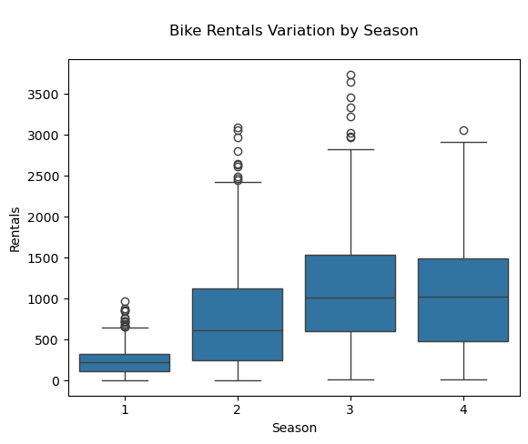

```python
# boxplot comparing season and rentals
sns.boxplot (x = 'Season',
            y = 'Rentals',
            data = bikes_data,)

# customization of the boxplot
plt.title(label = """
Bike Rentals Variation by Season
""")

# displaying the visual
plt.show(block = True)
```

### Season vs. Rentals Boxplot

When comparing the distribution of rentals with season, we can see that **Winter** is in the bottom range, with a median of less than 500 rentals, around 200 to 300, with the interquartile range being narrow, indicating that demand is consistently low during Winter, with some extreme rentals days.

**Spring** shows a drastic difference from the previous season, the median climbs to over 500 and has a greater variability, with some outliers hitting over 3000 rentals per day. This points out that users feel more comfortable using rental bikes during warmer periods.

```python
# defining filters
winter_def   = (bikes_data.loc[ : , 'Season']    == 1)
rental_def   = (bikes_data.loc[ : , 'Rentals']   >= 700)

# printing out the results
bikes_data[winter_def][rental_def]
```

|  | Id | Month | Day Of Week | Hour | Temperature | Humidity | Wind Speed | Visibility | Dew Point Temperature | Uv Index | Rainfall | Snowfall | Season | Holiday | Rentals |
| --- | --- | --- | --- | --- | --- | --- | --- | --- | --- | --- | --- | --- | --- | --- | --- |
| 6 | 7 | 1 | 1 | 18 | -0.8 | 24 | 2.3 | 2000 | -18.9 | 0.01 | 0.0 | 0.0 | 1 | 0 | 723 |
| 156 | 157 | 2 | 4 | 18 | 4.1 | 40 | 2.1 | 1327 | -8.3 | 0.10 | 0.0 | 0.0 | 1 | 0 | 712 |
| 199 | 200 | 2 | 1 | 8 | -2.1 | 71 | 1.7 | 610 | -6.6 | 0.06 | 0.0 | 0.0 | 1 | 0 | 764 |
| 208 | 209 | 2 | 3 | 18 | 3.9 | 56 | 4.0 | 1004 | -4.0 | 0.18 | 0.0 | 0.0 | 1 | 0 | 767 |
| 216 | 217 | 2 | 6 | 16 | 7.6 | 18 | 3.2 | 1930 | -15.2 | 1.73 | 0.0 | 0.0 | 1 | 0 | 730 |
| 217 | 218 | 2 | 7 | 8 | -2.9 | 63 | 0.7 | 1386 | -8.9 | 0.11 | 0.0 | 0.0 | 1 | 0 | 857 |
| 222 | 223 | 2 | 1 | 18 | 6.6 | 62 | 0.8 | 522 | -0.1 | 0.05 | 0.0 | 0.0 | 1 | 0 | 969 |
| 223 | 224 | 2 | 2 | 8 | 5.7 | 57 | 2.5 | 458 | -2.1 | 0.04 | 0.0 | 0.0 | 1 | 0 | 882 |
| 1288 | 1289 | 12 | 1 | 18 | -2.1 | 29 | 3.9 | 2000 | -17.7 | 0.00 | 0.0 | 0.0 | 1 | 0 | 864 |
| 1289 | 1290 | 12 | 2 | 8 | -8.1 | 36 | 1.6 | 2000 | -20.5 | 0.01 | 0.0 | 0.0 | 1 | 0 | 853 |
| 1349 | 1350 | 12 | 5 | 18 | 4.9 | 63 | 0.6 | 677 | -1.5 | 0.00 | 0.0 | 0.0 | 1 | 1 | 725 |

### Winter Peak Days Analysis

Following the Rentals vs. Season boxplot, we can proceed to investigate the cause of the outliers on low demand seasons. When we isolate Winter season and high rentals, a pattern emerges:

- Most of the rentals in peak day happen during the morning and evening commute window, 8am and 6pm.
- Renting bikes is also a viable option when days are clearer (visibility generally above 1000), and with dryer days (no rain or snowfall)

Finally, although winter registers generally lower demand, these outliers demonstrate that users sees bike rentals as a convenient way of commuting during brighter and dryer days. The company should consider these for a dynamic fleet allocation and target more availability during weekdays and promotions for peak commute hours users.

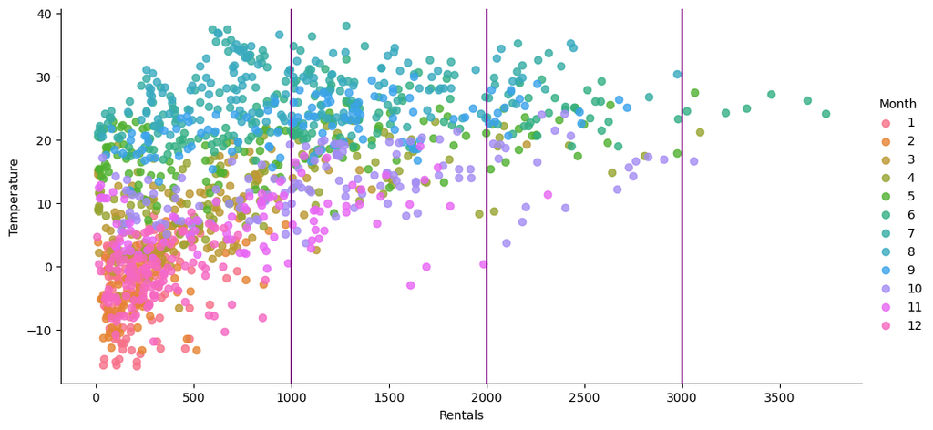

```python
# instantiating a scatter plot for month, temperatyre and rentals
sns.lmplot(x          = 'Rentals'     ,
           y          = 'Temperature' ,
           hue        = 'Month'       ,
           scatter    = True          ,
           fit_reg    = False         ,
           aspect     = 2             ,
           data       = bikes_data)


# adding and personalizing reference lines
plt.axvline(x = 1000, color = 'purple')
plt.axvline(x = 2000, color = 'purple')
plt.axvline(x = 3000, color = 'purple')
```

### Month & Temperature vs. Rentals (Part I)

As stated before, warmer temperature drives the outliers further to the right, meaning more rentals, and the scatter plot above reinforces this.

Colder days generally result in fewer rentals, which is highlighted by colder temperature markers being grouped mostly in the first segment of the plot. Here we can find December, January, and February (winter months), with no outliers moving after the first vertical demarcation.

Following the summer season, autumn experiences many days with comfortable temperatures, translating into higher rental volume when compared to other transitional seasons.

Although warmer days generally see more frequent rentals, the plot reveals that excessive heat often harms demand, since it impacts users' comfort and, consequently, their preference for utilizing the service. Days where the temperature hits above 30 degrees cluster in the first and second division lines (mid-demand), while Summer days that see peak rentals are usually around or below 30 degrees, but above 20 degrees.

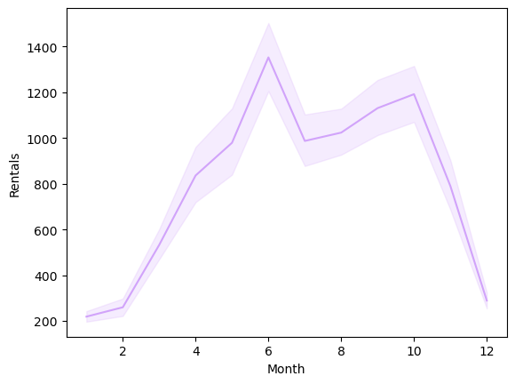

```python
# instantiating lineplot for month and rentals
sns.lineplot( x     = 'Month'   ,
              y     = 'Rentals' ,
              color = '#d1a3fa' ,
              data  = bikes_data)
```

### Month & Temperature vs. Rentals (Part II)

Additionally, it facilitates the view of the months where rental steeply decreases. This drastic drop remains constant for during November and December, and increases slowly throughout January and February. With adequate strategies, the abrupt drop can be softened with off-season promotions and targeted marketing during clearer days.

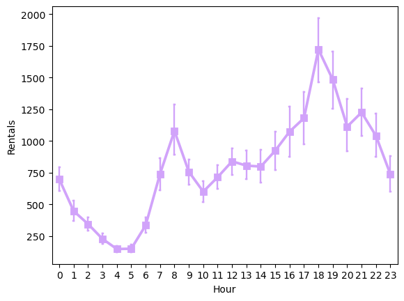

```python
# instantiating a pointplot for hour and rentals
sns.pointplot(x         = 'Hour'    ,
              y         = 'Rentals' ,
              data      = bikes_data,
              estimator = "mean"    ,
              color     = '#d1a3fa' ,
              markers   = 's'       ,
              scale     = 1         ,
              errwidth  = 1.7       ,
              capsize   = 0.05)
```

### Hour vs. Rentals

The continuous time plot showcases the rental variation during hourly periods, and because there is a lot of details to uncover, we'll explore through sections:

- **Low movement**

The overnight time faces a consistent drop on rentals starting from the evening peak at 9 pm, and only starts rising up again around 6 am.

- **First peak**

As movement starts to ramp up at 6 am, rentals see a steep growth until it reaches its first peak at 8 am, a common commute time morning window, indicating users' preference for rental bikes as a form of transportation to work.

- **Last peak**

The last peak happens at 9 pm, indicating that users still utilize the services for personal leisure time, after that, the usage continuously drop until morning hours.

- **Invisible details**

The bars outside the squares indicate the variability inside each times, meaning that during overnight time there is last variability, it is constantly low volume of rentals, while during peak hours the variation is higher.

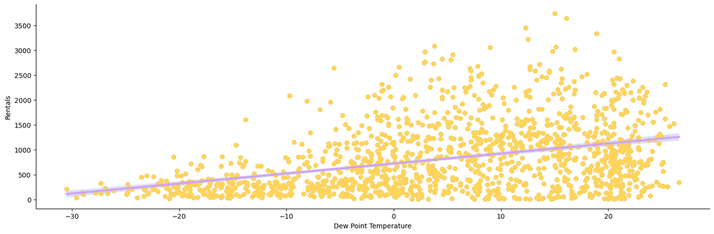

```python
# instantiating an lmplot for dew point and rentals
sns.lmplot(x       = 'Dew Point Temperature' ,
           y       = 'Rentals'               ,
           hue     = None                    ,
           scatter = True                    ,
           fit_reg = True                    ,
           aspect  = 3                       ,
           data    = bikes_data)

# colors and adjustments to plot
sns.regplot(x           = 'Dew Point Temperature'               ,
            y           = 'Rentals'                             ,
            data        = bikes_data                            ,
            scatter_kws = {'s':40, 'alpha':1, 'color':'#ffd45a'},
            line_kws    = {'linewidth':3, 'color':'#d1a3fa'})
```

### Dew Point Temperature vs. Rentals

Dew Point Temperature indicates how warm and humid the air is, leading to more or less comfort, depending on the temperature. The point of -30 indicates colder, drier days, while the other edge, 30, indicates more moisture and more warmth. Translating this extreme to an average, a comfortable Dew Point temperature would be from 5 to 20 degrees.

It is possible to observe that users tend to prefer more humid days than dry days, this happens because warmer weathers tend to be more humid too, and our users already have a strong preference for warmer days. This can be showcased by the rentals outliers, mainly the ones above 2500, who are positioned around 5 to 20 degrees.

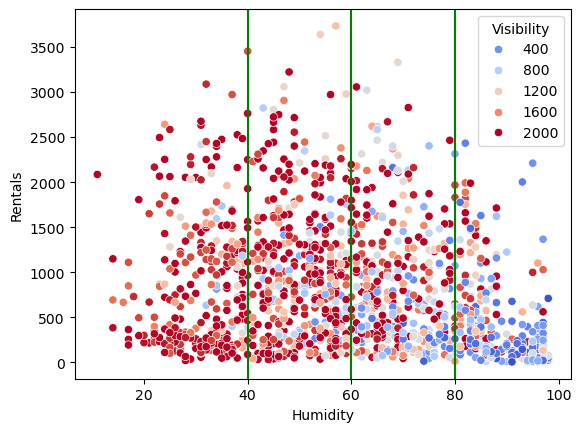

```python
# creating scatter plot for moderate relationship variables
sns.scatterplot(x = 'Humidity'    ,
                y = 'Rentals'     ,
                hue = 'Visibility',
                palette='coolwarm',
               data = bikes_data)

# adding and personalizing reference lines
plt.axvline(x = 40, color = 'green')
plt.axvline(x = 60, color = 'green')
plt.axvline(x = 80, color = 'green')
```

### Humidity & Visibility vs. Rentals

Humidity and Visibility have a moderate relationship with rentals. Although their impact is moderate, they still add significant value to the analysis. Hence, this scatter plot compares rental counts with humidity (x-axis) and visibility (color).

Our Dew Point Temperature visualization indicated that users have preference for warmer and moderate humid days.

Days with lower visibility (darker blues hues) tend to exhibit higher humidity, as evidenced by the clustering of darker blues in the last two areas. In contrast, days with better visibility are, generally, less humid.

When focusing on the peak rental days (y-axis), we can see that users tend to utilize the services during days with high visibility, with a slight preference for days with low to moderate humidity.

## Conclusion

The bike rental service faces impacts from different variables, varying from high to low relationships between them. The visuals and analysis allowed us to understand preferences and patterns in the customers behavior that can lead to better strategies to retain one-time users, fortify relationships with frequent users, and acquire new users.

Data also illustrates that riders tend to utilize the vehicle during commute hours, implying that most users rent bikes to commute, which provides the company with the information necessary to generate promotions and allocate the amount of bikes necessary to attend demand.